# Transformers: Basics to Expert

A single, self-contained course on the **Transformer** — the architecture behind GPT, BERT, Claude, and essentially all of modern AI. We start with tokens and attention as raw NumPy, build every block from scratch in PyTorch, train a full encoder–decoder Transformer and a char-level GPT, then cover the expert layer: KV caching, sampling, RoPE, LoRA fine-tuning, scaling laws, and efficient attention. (This picks up where sections 20–21 of `deep_learning_basics_to_expert.ipynb` left off.)

**How to read this notebook:** every section builds one idea, shows the math, codes it from first principles, and ends with the production-grade equivalent. Everything runs on CPU in a few minutes. Run cells top to bottom.

### Contents

[output not shown]

```python
import math, time
import numpy as np
import matplotlib.pyplot as plt
from cycler import cycler
import torch
import torch.nn as nn
import torch.nn.functional as F

print("numpy:", np.__version__, "| torch:", torch.__version__)

# One fixed, colorblind-safe categorical palette used throughout the notebook
# (assigned in this fixed order, never re-shuffled per chart).
PALETTE = ["#2a78d6", "#1baf7a", "#eda100", "#008300",
           "#4a3aa7", "#e34948", "#e87ba4", "#eb6834"]
GRAY = "#898781"

plt.rcParams.update({
    "axes.prop_cycle": cycler(color=PALETTE),
    "axes.grid": True, "grid.color": "#e1e0d9", "grid.linewidth": 0.8,
    "axes.spines.top": False, "axes.spines.right": False,
    "axes.edgecolor": "#c3c2b7",
    "axes.labelcolor": "#52514e", "axes.titlecolor": "#0b0b0b",
    "xtick.color": GRAY, "ytick.color": GRAY,
    "figure.dpi": 100, "figure.facecolor": "white",
})

rng = np.random.default_rng(42)   # one seeded generator for the whole notebook
torch.manual_seed(42);
```

```
numpy: 2.3.1 | torch: 2.4.1+cpu
```

## 1. Why Transformers?

Before 2017, sequence models were **recurrent**: an RNN/LSTM reads tokens one at a time, squeezing everything seen so far into one hidden vector. Two problems follow directly:

1. **Long-range information decays.** For token 500 to influence token 900, its signal must survive 400 sequential updates of the same hidden state.
2. **No parallelism.** Step $t$ needs step $t-1$, so training can't use the full width of a GPU across the sequence.

The Transformer (*Attention Is All You Need*, Vaswani et al. 2017) removes recurrence entirely. Every token **directly attends** to every other token in one matrix multiply — the path between any two positions has length 1, and the whole sequence is processed at once.

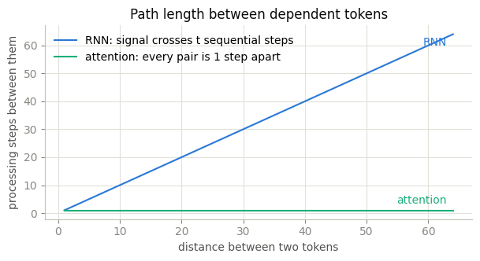

```python
dist = np.arange(1, 65)
fig, ax = plt.subplots(figsize=(7, 3.2))
ax.plot(dist, dist, label="RNN: signal crosses t sequential steps")
ax.plot(dist, np.ones_like(dist), label="attention: every pair is 1 step apart")
ax.text(63, 60, "RNN", color=PALETTE[0], ha="right")
ax.text(63, 3.5, "attention", color=PALETTE[1], ha="right")
ax.set_xlabel("distance between two tokens")
ax.set_ylabel("processing steps between them")
ax.set_title("Path length between dependent tokens")
ax.legend(frameon=False);
```

That single change is why context windows grew from ~100 tokens (LSTM era) to millions, and why the same architecture now handles text, images, audio, and protein sequences. The price: attention compares **every pair** of tokens, so cost grows as $O(n^2)$ with sequence length — we return to that in section 24.

## 2. Tokenization & BPE

A Transformer never sees text — it sees **integer IDs**. A *tokenizer* maps text to IDs and back. The simplest is character-level:

```python
sentence = "attention is all you need"

chars = sorted(set(sentence))
stoi = {ch: i for i, ch in enumerate(chars)}   # string -> int
itos = {i: ch for ch, i in stoi.items()}       # int   -> string

ids = [stoi[c] for c in sentence]
print("vocab:", "".join(chars), f"  ({len(chars)} tokens)")
print("encoded:", ids[:12], "...")
print("decoded:", "".join(itos[i] for i in ids))
```

```
vocab:  adeilnostuy   (12 tokens)
encoded: [1, 9, 9, 3, 6, 9, 4, 7, 6, 0, 4, 8] ...
decoded: attention is all you need
```

Character vocabularies are tiny but make sequences long and force the model to relearn spelling. Word vocabularies are compact per sentence but explode in size and can't handle unseen words. Production models use **Byte-Pair Encoding (BPE)** — start from characters and repeatedly merge the most frequent adjacent pair, so common words become single tokens while rare words fall back to pieces. Here is the whole algorithm:

```python
from collections import Counter

def bpe_train(words, n_merges):
    # each word is a tuple of symbols (starting as characters) with a corpus frequency
    vocab = Counter(tuple(w) + ("</w>",) for w in words)
    merges = []
    for _ in range(n_merges):
        pairs = Counter()
        for word, freq in vocab.items():
            for a, b in zip(word, word[1:]):
                pairs[(a, b)] += freq
        if not pairs:
            break
        best = max(pairs, key=pairs.get)          # most frequent adjacent pair
        merges.append(best)
        new_vocab = Counter()
        for word, freq in vocab.items():          # replace the pair everywhere
            merged, i = [], 0
            while i < len(word):
                if i < len(word) - 1 and (word[i], word[i + 1]) == best:
                    merged.append(word[i] + word[i + 1]); i += 2
                else:
                    merged.append(word[i]); i += 1
            new_vocab[tuple(merged)] += freq
        vocab = new_vocab
    return merges, vocab

corpus = ("low " * 5 + "lower " * 2 + "newest " * 6 + "widest " * 3).split()
merges, vocab = bpe_train(corpus, 10)

print("merges learned (in order):")
print("  " + ", ".join(a + "+" + b for a, b in merges))
print("\nwords as tokens after merging:")
for word, freq in vocab.items():
    print(f"  {' '.join(word):24s} (freq {freq})")
```

```
merges learned (in order):
  e+s, es+t, est+</w>, l+o, lo+w, n+e, ne+w, new+est</w>, low+</w>, w+i

words as tokens after merging:
  low</w>                  (freq 5)
  low e r </w>             (freq 2)
  newest</w>               (freq 6)
  wi d est</w>             (freq 3)
```

`est</w>` became one token because *newest* and *widest* share it — BPE discovers subword structure purely from frequency. GPT-2's tokenizer is exactly this, run for 50,000 merges over bytes instead of characters. Two practical consequences worth remembering:

- **Models see tokens, not letters** — that's why counting the r's in "strawberry" is hard.
- **Vocabulary size is a real design choice**: bigger vocab = shorter sequences but a larger embedding table (see section 25).

For the rest of this notebook we use character-level tokenization to keep everything inspectable.

## 3. Token embeddings

An ID like `17` carries no meaning. An **embedding table** — a learnable matrix $E \in \mathbb{R}^{V \times d}$ — turns each ID into a $d$-dimensional vector. Looking up row 17 is mathematically a one-hot vector times $E$, implemented as plain indexing:

```python
emb = nn.Embedding(num_embeddings=6, embedding_dim=4)   # V=6 tokens, d=4 dims

ids = torch.tensor([2, 5])
onehot = F.one_hot(ids, num_classes=6).float()

print("embedding table shape:", tuple(emb.weight.shape))
print("lookup == one-hot @ table:", torch.allclose(emb(ids), onehot @ emb.weight))
print("\nvector for token 2:", emb(ids)[0].detach().numpy().round(3))
```

```
embedding table shape: (6, 4)
lookup == one-hot @ table: True

vector for token 2: [ 0.356 -0.687 -0.493  0.241]
```

The table starts random; gradient descent moves rows so that tokens used in similar contexts end up with similar vectors. In a trained model, embeddings *are* the model's vocabulary of meaning — and the same table is often reused (transposed) as the output layer that scores next tokens, a trick called **weight tying** that we use in our GPT (section 18).

## 4. Positional encodings

Attention is a *set* operation — permute the tokens and (without extra information) the outputs permute identically. Word order would be invisible. The fix: add a **position vector** to each token embedding. The original paper used fixed sinusoids at geometrically spaced frequencies:

$$PE_{(pos,\,2i)} = \sin\!\frac{pos}{10000^{2i/d}} \qquad PE_{(pos,\,2i+1)} = \cos\!\frac{pos}{10000^{2i/d}}$$

Each position gets a unique fingerprint; nearby positions get similar fingerprints.

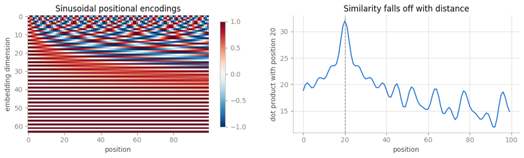

```python
def sinusoidal_pe(n_pos, d):
    pos = np.arange(n_pos)[:, None]
    i = np.arange(d)[None, :]
    angles = pos / np.power(10000.0, 2 * (i // 2) / d)
    pe = np.zeros((n_pos, d))
    pe[:, 0::2] = np.sin(angles[:, 0::2])
    pe[:, 1::2] = np.cos(angles[:, 1::2])
    return pe

pe = sinusoidal_pe(100, 64)

fig, axes = plt.subplots(1, 2, figsize=(11, 3.4))
im = axes[0].imshow(pe.T, aspect="auto", cmap="RdBu_r", vmin=-1, vmax=1)
axes[0].set_xlabel("position"); axes[0].set_ylabel("embedding dimension")
axes[0].set_title("Sinusoidal positional encodings"); axes[0].grid(False)
fig.colorbar(im, ax=axes[0], shrink=0.9)

sims = pe @ pe[20]                       # dot product of every position with position 20
axes[1].plot(sims)
axes[1].axvline(20, color=GRAY, ls="--", lw=1)
axes[1].set_xlabel("position"); axes[1].set_ylabel("dot product with position 20")
axes[1].set_title("Similarity falls off with distance")
plt.tight_layout();
```

Left: low dimensions oscillate fast, high dimensions slowly — like digits of a binary/clock counter, giving every position a unique code. Right: the dot product between position vectors peaks at the position itself and decays with distance, so attention can learn "look nearby" as easily as "look at position 7".

Alternatives you will meet: **learned absolute** positions (GPT-2, an `nn.Embedding` over positions — used in our GPT below) and **RoPE**, rotary embeddings applied inside attention (LLaMA and most modern LLMs — built from scratch in section 23).

## 5. Queries, keys, values

Attention is a **soft dictionary lookup**. A normal dict compares your query against keys and returns *one* value. Attention compares a query vector against all key vectors and returns a **weighted average of all values**, weights given by match quality.

Concretely, with a database of 4 items, each having a key (what it's matchable by) and a value (what it returns):

```python
labels = ["cat", "dog", "car", "truck"]
# key = [animal-ness, vehicle-ness]         value = [weight kg, top speed km/h]
keys   = np.array([[1.0, 0.0], [0.9, 0.1], [0.0, 1.0], [0.1, 0.9]])
values = np.array([[4.0, 48.0], [30.0, 45.0], [1500.0, 200.0], [9000.0, 120.0]])

def softmax_np(x, axis=-1):
    e = np.exp(x - x.max(axis=axis, keepdims=True))
    return e / e.sum(axis=axis, keepdims=True)

query = np.array([0.95, 0.05])            # "something very animal-like"
scores = keys @ query                     # similarity of query to each key
weights = softmax_np(scores * 8)          # sharpened for the demo

print("scores :", dict(zip(labels, scores.round(2))))
print("weights:", dict(zip(labels, weights.round(3))))
print("answer :", (weights @ values).round(1), " <- mostly a blend of cat & dog")
```

```
scores : {'cat': np.float64(0.95), 'dog': np.float64(0.86), 'car': np.float64(0.05), 'truck': np.float64(0.14)}
weights: {'cat': np.float64(0.672), 'dog': np.float64(0.327), 'car': np.float64(0.001), 'truck': np.float64(0.001)}
answer : [22.5 47.2]  <- mostly a blend of cat & dog
```

In a Transformer, every token plays all three roles at once. From each token's vector $x$ we compute three projections with learned matrices:

- **query** $q = x W_Q$ — *what am I looking for?*
- **key** $k = x W_K$ — *what can I be found by?*
- **value** $v = x W_V$ — *what do I contribute if found?*

A pronoun's query might seek "recent noun"; a noun's key advertises "I am a noun"; its value carries its meaning. The lookup above, done for every token against every token simultaneously, is the next section.

## 6. Scaled dot-product attention

The core equation of the last decade of AI:

$$\text{Attention}(Q, K, V) = \text{softmax}\!\left(\frac{QK^\top}{\sqrt{d_k}}\right)V$$

$Q \in \mathbb{R}^{n \times d_k}$ holds one query per row, $K$ one key per row: $QK^\top$ is the $n \times n$ matrix of **all pairwise scores** in one multiply. Softmax over each row turns scores into weights; multiplying by $V$ mixes values. In NumPy:

```python
def attention_np(Q, K, V, mask=None, scale=True):
    d_k = Q.shape[-1]
    scores = Q @ K.T
    if scale:
        scores = scores / np.sqrt(d_k)
    if mask is not None:
        scores = np.where(mask == 0, -1e9, scores)   # blocked positions -> ~zero weight
    weights = softmax_np(scores)
    return weights @ V, weights

n, d_k = 5, 16
Q, K, V = rng.normal(size=(n, d_k)), rng.normal(size=(n, d_k)), rng.normal(size=(n, d_k))
out, w = attention_np(Q, K, V)

print("output shape:", out.shape, "   weights shape:", w.shape)
print("each weight row sums to 1:", np.allclose(w.sum(axis=1), 1))
```

```
output shape: (5, 16)    weights shape: (5, 5)
each weight row sums to 1: True
```

**Why divide by $\sqrt{d_k}$?** Dot products of random $d_k$-dim vectors have standard deviation $\sqrt{d_k}$ — scores grow with dimension. Big scores push softmax into saturation: one weight ≈ 1, the rest ≈ 0, and (worse for training) near-zero gradients. Scaling keeps score variance at 1 regardless of dimension:

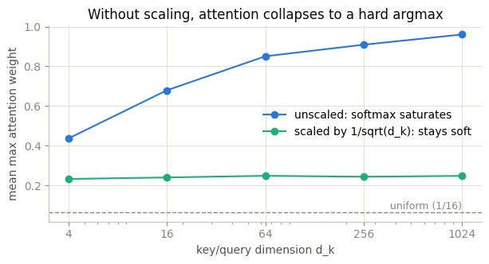

```python
dims, n_keys, trials = [4, 16, 64, 256, 1024], 16, 200
max_w = {True: [], False: []}
for d in dims:
    for scale in (True, False):
        ws = []
        for _ in range(trials):
            q = rng.normal(size=(1, d)); k = rng.normal(size=(n_keys, d))
            s = (q @ k.T) / (np.sqrt(d) if scale else 1.0)
            ws.append(softmax_np(s).max())
        max_w[scale].append(np.mean(ws))

fig, ax = plt.subplots(figsize=(7, 3.2))
ax.plot(dims, max_w[False], marker="o", label="unscaled: softmax saturates")
ax.plot(dims, max_w[True], marker="o", label="scaled by 1/sqrt(d_k): stays soft")
ax.axhline(1 / n_keys, color=GRAY, ls="--", lw=1)
ax.text(dims[-1], 1 / n_keys + 0.02, "uniform (1/16)", color=GRAY, ha="right", fontsize=9)
ax.set_xscale("log"); ax.set_xticks(dims); ax.set_xticklabels(dims)
ax.set_xlabel("key/query dimension d_k"); ax.set_ylabel("mean max attention weight")
ax.set_title("Without scaling, attention collapses to a hard argmax")
ax.legend(frameon=False);
```

## 7. Masking

Two situations require *forbidding* certain attention edges. We set those scores to $-\infty$ **before** softmax, so their weight is exactly 0 and the remaining weights still sum to 1:

- **Causal mask** (decoders): token $t$ may only attend to positions $\le t$ — otherwise next-token prediction could just copy the answer from the future.
- **Padding mask** (batches): sequences of different lengths are padded to equal length; nothing should attend to pad tokens.

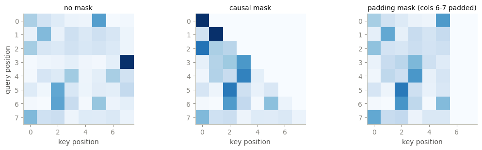

```python
L = 8
causal = np.tril(np.ones((L, L)))                # 1 = allowed, 0 = blocked

Q = rng.normal(size=(L, 12)); K = rng.normal(size=(L, 12)); V = rng.normal(size=(L, 12))
_, w_free   = attention_np(Q, K, V)
_, w_causal = attention_np(Q, K, V, mask=causal)

pad_mask = np.ones((L, L)); pad_mask[:, 6:] = 0  # last two positions are padding
_, w_pad = attention_np(Q, K, V, mask=pad_mask)

fig, axes = plt.subplots(1, 3, figsize=(11, 3.2))
for ax, w, title in zip(axes, [w_free, w_causal, w_pad],
                        ["no mask", "causal mask", "padding mask (cols 6-7 padded)"]):
    ax.imshow(w, cmap="Blues", vmin=0, vmax=w_free.max())
    ax.set_title(title, fontsize=10); ax.grid(False)
    ax.set_xlabel("key position")
axes[0].set_ylabel("query position")
plt.tight_layout();
```

The causal panel shows the signature lower-triangular pattern — row $t$ has weight only on columns $0..t$. Every GPT-style model you have ever used has this triangle inside it. In the padding panel, the padded columns receive zero weight from every query.

## 8. Multi-head attention

One attention pattern per layer is a bottleneck: a token might *simultaneously* need syntax from nearby words and a referent from 50 tokens back. **Multi-head attention** runs $h$ attentions in parallel, each in a $d_{model}/h$-dimensional subspace with its own learned $W_Q, W_K, W_V$ — then concatenates the results and mixes them with an output projection $W_O$.

The efficient implementation projects once to $d_{model}$ and *reshapes* into heads:

```python
class MultiHeadAttention(nn.Module):
    def __init__(self, d_model, n_heads, dropout=0.1):
        super().__init__()
        assert d_model % n_heads == 0
        self.n_heads, self.d_head = n_heads, d_model // n_heads
        self.wq = nn.Linear(d_model, d_model)
        self.wk = nn.Linear(d_model, d_model)
        self.wv = nn.Linear(d_model, d_model)
        self.wo = nn.Linear(d_model, d_model)
        self.drop = nn.Dropout(dropout)

    def forward(self, q, k, v, mask=None):
        B, Lq, D = q.shape
        Lk = k.shape[1]
        split = lambda x, L: x.view(B, L, self.n_heads, self.d_head).transpose(1, 2)
        Q = split(self.wq(q), Lq)                    # (B, heads, Lq, d_head)
        K = split(self.wk(k), Lk)
        V = split(self.wv(v), Lk)
        scores = Q @ K.transpose(-2, -1) / math.sqrt(self.d_head)   # (B, heads, Lq, Lk)
        if mask is not None:
            scores = scores.masked_fill(mask == 0, float("-inf"))
        attn = self.drop(torch.softmax(scores, dim=-1))
        out = (attn @ V).transpose(1, 2).reshape(B, Lq, D)          # concat heads
        return self.wo(out), attn

mha = MultiHeadAttention(d_model=64, n_heads=4, dropout=0.0)
x = torch.randn(2, 10, 64)
out, attn = mha(x, x, x)
print("output:", tuple(out.shape), "  attention:", tuple(attn.shape), " (B, heads, Lq, Lk)")
```

```
output: (2, 10, 64)   attention: (2, 4, 10, 10)  (B, heads, Lq, Lk)
```

Sanity check: load our weights into `nn.MultiheadAttention` (which packs $W_Q, W_K, W_V$ into one matrix) and confirm both produce identical outputs — proof our from-scratch module is the real thing, not an approximation:

```python
ref = nn.MultiheadAttention(embed_dim=64, num_heads=4, batch_first=True)
E = 64
with torch.no_grad():
    mha.wq.weight.copy_(ref.in_proj_weight[:E]);      mha.wq.bias.copy_(ref.in_proj_bias[:E])
    mha.wk.weight.copy_(ref.in_proj_weight[E:2*E]);   mha.wk.bias.copy_(ref.in_proj_bias[E:2*E])
    mha.wv.weight.copy_(ref.in_proj_weight[2*E:]);    mha.wv.bias.copy_(ref.in_proj_bias[2*E:])
    mha.wo.weight.copy_(ref.out_proj.weight);         mha.wo.bias.copy_(ref.out_proj.bias)

ours, _ = mha(x, x, x)
theirs, _ = ref(x, x, x)
print("max difference vs nn.MultiheadAttention:", (ours - theirs).abs().max().item())
```

```
max difference vs nn.MultiheadAttention: 1.1920928955078125e-07
```

## 9. The feed-forward network

Attention *moves* information between tokens but is (almost) linear in the values. After each attention step, every token is passed — independently, in parallel — through a small two-layer MLP that expands to $d_{ff} \approx 4\,d_{model}$ and contracts back:

$$\text{FFN}(x) = W_2\,\phi(W_1 x + b_1) + b_2$$

A useful mental model: **attention gathers, the FFN thinks.** The FFN holds roughly two thirds of a Transformer's parameters and is where much of its factual knowledge appears to live. Modern models use **GELU** (a smooth ReLU that weights inputs by how positive they are) instead of ReLU:

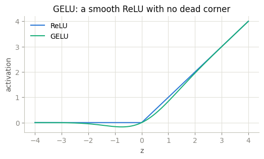

```python
class FeedForward(nn.Module):
    def __init__(self, d_model, d_ff, dropout=0.1):
        super().__init__()
        self.net = nn.Sequential(
            nn.Linear(d_model, d_ff), nn.GELU(),
            nn.Dropout(dropout), nn.Linear(d_ff, d_model),
        )
    def forward(self, x):
        return self.net(x)

z = torch.linspace(-4, 4, 200)
fig, ax = plt.subplots(figsize=(6, 3))
ax.plot(z, F.relu(z), label="ReLU")
ax.plot(z, F.gelu(z), label="GELU")
ax.set_xlabel("z"); ax.set_ylabel("activation")
ax.set_title("GELU: a smooth ReLU with no dead corner")
ax.legend(frameon=False);
```

## 10. LayerNorm & residual connections

Two pieces of plumbing make deep Transformers trainable:

**Residual connections** — every sublayer computes $x + \text{sublayer}(x)$, so there is an uninterrupted "highway" from input to output. Gradients flow through the $+\,x$ path even if the sublayer misbehaves; think of the residual stream as a shared workspace that attention and FFN read from and write small updates into.

**LayerNorm** — normalizes each token's vector to zero mean and unit variance (then applies a learned scale and shift), keeping activations in a healthy range at every depth:

```python
def layer_norm_np(x, gamma=1.0, beta=0.0, eps=1e-5):
    mu = x.mean(axis=-1, keepdims=True)
    var = x.var(axis=-1, keepdims=True)
    return gamma * (x - mu) / np.sqrt(var + eps) + beta

x_np = rng.normal(loc=3.0, scale=5.0, size=(2, 8))       # ugly statistics in...
ours = layer_norm_np(x_np)
torchs = nn.LayerNorm(8)(torch.tensor(x_np, dtype=torch.float32)).detach().numpy()

print("normalized mean ~0:", ours.mean(-1).round(6), " std ~1:", ours.std(-1).round(3))
print("matches nn.LayerNorm:", np.allclose(ours, torchs, atol=1e-5))
```

```
normalized mean ~0: [0. 0.]  std ~1: [1. 1.]
matches nn.LayerNorm: True
```

**Where the norm goes matters.** The 2017 paper used **post-LN** ($\text{LN}(x + \text{sublayer}(x))$), which needs learning-rate warmup to avoid early divergence. Modern models use **pre-LN** ($x + \text{sublayer}(\text{LN}(x))$): the residual path stays untouched, gradients are stable from step 1, and very deep stacks train reliably. We build everything pre-LN.

## 11. The encoder block

We now have every ingredient. An encoder block is just:

```
x = x + Dropout(MultiHeadAttention(LN(x)))     # tokens exchange information
x = x + Dropout(FFN(LN(x)))                    # each token processes what it gathered
```

Stack $N$ of these and you have BERT's body. Note how little code is left to write:

```python
class EncoderBlock(nn.Module):
    def __init__(self, d_model, n_heads, d_ff, dropout=0.1):
        super().__init__()
        self.ln1 = nn.LayerNorm(d_model)
        self.ln2 = nn.LayerNorm(d_model)
        self.attn = MultiHeadAttention(d_model, n_heads, dropout)
        self.ffn = FeedForward(d_model, d_ff, dropout)
        self.drop = nn.Dropout(dropout)

    def forward(self, x, mask=None):
        h = self.ln1(x)
        a, _ = self.attn(h, h, h, mask)          # self-attention: q, k, v all from x
        x = x + self.drop(a)
        x = x + self.drop(self.ffn(self.ln2(x)))
        return x

blocks = nn.Sequential(*[EncoderBlock(64, 4, 128) for _ in range(6)])
x = torch.randn(2, 10, 64)
h = x
for i, blk in enumerate(blocks):
    h = blk(h)
    if i % 2 == 1:
        print(f"after block {i+1}: shape {tuple(h.shape)}, std {h.std().item():.2f}")
```

```
after block 2: shape (2, 10, 64), std 1.09
after block 4: shape (2, 10, 64), std 1.15
after block 6: shape (2, 10, 64), std 1.27
```

Shapes never change — every block maps $(B, L, d_{model}) \to (B, L, d_{model})$ — and thanks to pre-LN the activation scale grows only gently with depth instead of exploding. That shape-preserving property is what makes Transformers so stackable: GPT-3 is this block repeated 96 times.

## 12. The decoder block & cross-attention

A decoder block generates output tokens while consulting the encoder. It has **three** sublayers:

1. **Masked self-attention** — output tokens attend to previous output tokens (causal mask).
2. **Cross-attention** — the bridge: queries come from the *decoder*, keys and values from the *encoder's* output. This is where translation "looks at the source sentence".
3. **FFN** — as before.

```python
class DecoderBlock(nn.Module):
    def __init__(self, d_model, n_heads, d_ff, dropout=0.1):
        super().__init__()
        self.ln1 = nn.LayerNorm(d_model)
        self.ln2 = nn.LayerNorm(d_model)
        self.ln3 = nn.LayerNorm(d_model)
        self.self_attn = MultiHeadAttention(d_model, n_heads, dropout)
        self.cross_attn = MultiHeadAttention(d_model, n_heads, dropout)
        self.ffn = FeedForward(d_model, d_ff, dropout)
        self.drop = nn.Dropout(dropout)

    def forward(self, x, memory, causal_mask):
        h = self.ln1(x)
        a, _ = self.self_attn(h, h, h, causal_mask)
        x = x + self.drop(a)
        a, attn = self.cross_attn(self.ln2(x), memory, memory)   # q from decoder, k/v from encoder
        self.last_cross_attn = attn.detach()                     # saved for visualization later
        x = x + self.drop(a)
        x = x + self.drop(self.ffn(self.ln3(x)))
        return x

dec = DecoderBlock(64, 4, 128)
tgt, memory = torch.randn(2, 7, 64), torch.randn(2, 10, 64)
causal = torch.tril(torch.ones(7, 7, dtype=torch.bool))
out = dec(tgt, memory, causal)
print("decoder out:", tuple(out.shape), "  cross-attention:", tuple(dec.last_cross_attn.shape))
```

```
decoder out: (2, 7, 64)   cross-attention: (2, 4, 7, 10)
```

## 13. The full Transformer

Assembling the original encoder–decoder architecture: embed + positional-encode the source, run it through encoder blocks to get `memory`; embed the target-so-far, run decoder blocks against that memory; project to vocabulary logits. (Embeddings are scaled by $\sqrt{d_{model}}$ as in the paper, so they start at the same magnitude as the positional encodings.)

```python
class Seq2SeqTransformer(nn.Module):
    def __init__(self, vocab, d_model=64, n_heads=4, n_enc=2, n_dec=2,
                 d_ff=128, max_len=32, dropout=0.1):
        super().__init__()
        self.d_model = d_model
        self.src_emb = nn.Embedding(vocab, d_model)
        self.tgt_emb = nn.Embedding(vocab, d_model)
        # init so that (embedding * sqrt(d)) and the positional encoding have
        # comparable magnitude — with the default N(0,1) init the position
        # signal would be drowned out and the model couldn't learn order
        nn.init.normal_(self.src_emb.weight, std=d_model ** -0.5)
        nn.init.normal_(self.tgt_emb.weight, std=d_model ** -0.5)
        pe = torch.tensor(sinusoidal_pe(max_len, d_model), dtype=torch.float32)
        self.register_buffer("pe", pe)
        self.drop = nn.Dropout(dropout)
        self.encoder = nn.ModuleList([EncoderBlock(d_model, n_heads, d_ff, dropout)
                                      for _ in range(n_enc)])
        self.decoder = nn.ModuleList([DecoderBlock(d_model, n_heads, d_ff, dropout)
                                      for _ in range(n_dec)])
        self.ln_enc = nn.LayerNorm(d_model)
        self.ln_dec = nn.LayerNorm(d_model)
        self.out = nn.Linear(d_model, vocab)

    def encode(self, src):
        x = self.drop(self.src_emb(src) * math.sqrt(self.d_model) + self.pe[:src.shape[1]])
        for blk in self.encoder:
            x = blk(x)
        return self.ln_enc(x)

    def decode(self, tgt, memory):
        L = tgt.shape[1]
        causal = torch.tril(torch.ones(L, L, dtype=torch.bool, device=tgt.device))
        x = self.drop(self.tgt_emb(tgt) * math.sqrt(self.d_model) + self.pe[:L])
        for blk in self.decoder:
            x = blk(x, memory, causal)
        return self.out(self.ln_dec(x))

    def forward(self, src, tgt_in):
        return self.decode(tgt_in, self.encode(src))

model = Seq2SeqTransformer(vocab=11)
n_params = sum(p.numel() for p in model.parameters())
print(f"a complete Transformer in ~60 lines: {n_params:,} parameters")
```

```
a complete Transformer in ~60 lines: 169,803 parameters
```

## 14. Toy translation: reversing sequences

Time to train it. Our "translation" task: given a sequence of digits, output it **reversed** (`3 1 4 1 5 → 5 1 4 1 3`). Trivial for us, but the model must *learn* it from examples — and it's a real seq2seq problem requiring the decoder to attend to the right source position at every step.

Training uses **teacher forcing**: the decoder is fed the *true* previous tokens (shifted right, starting with a BOS token) and predicts every next token in parallel — one forward pass per sequence, not one per token.

```
trained 600 steps in 34.0s | final loss 0.0384
```

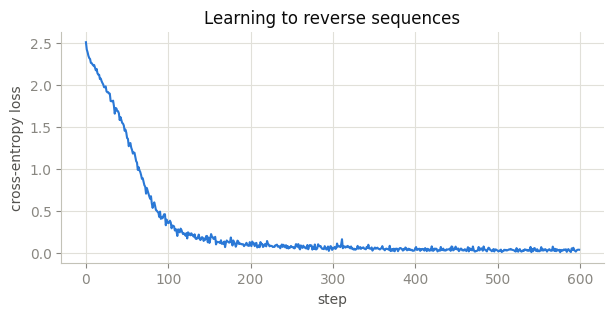

```python
BOS, V, L_SEQ = 10, 11, 8      # tokens 0-9 are digits, 10 is beginning-of-sequence

def make_batch(n):
    src = torch.randint(0, 10, (n, L_SEQ))
    tgt = src.flip(1)                                            # the "translation"
    dec_in = torch.cat([torch.full((n, 1), BOS), tgt[:, :-1]], dim=1)   # shifted right
    return src, dec_in, tgt

model = Seq2SeqTransformer(vocab=V)
opt = torch.optim.Adam(model.parameters(), lr=1e-3)

losses = []
t0 = time.time()
for step in range(600):
    src, dec_in, tgt = make_batch(64)
    logits = model(src, dec_in)
    loss = F.cross_entropy(logits.reshape(-1, V), tgt.reshape(-1))
    opt.zero_grad(); loss.backward(); opt.step()
    losses.append(loss.item())
print(f"trained 600 steps in {time.time()-t0:.1f}s | final loss {losses[-1]:.4f}")

fig, ax = plt.subplots(figsize=(7, 3))
ax.plot(losses)
ax.set_xlabel("step"); ax.set_ylabel("cross-entropy loss")
ax.set_title("Learning to reverse sequences");
```

At inference time there is no ground truth to feed the decoder, so we generate **autoregressively**: start with BOS, predict a token, append it, repeat — the decoder consumes its own output:

```python
@torch.no_grad()
def greedy_decode(model, src):
    model.eval()
    memory = model.encode(src)
    ys = torch.full((src.shape[0], 1), BOS)
    for _ in range(L_SEQ):
        logits = model.decode(ys, memory)
        nxt = logits[:, -1].argmax(-1, keepdim=True)   # most likely next token
        ys = torch.cat([ys, nxt], dim=1)
    return ys[:, 1:]                                   # drop BOS

src, _, tgt = make_batch(200)
pred = greedy_decode(model, src)
acc = (pred == tgt).all(dim=1).float().mean()

for i in range(3):
    print("src:", src[i].tolist(), " -> pred:", pred[i].tolist(),
          "| correct:", bool((pred[i] == tgt[i]).all()))
print(f"\nexact-sequence accuracy on 200 fresh examples: {acc:.1%}")
```

```
src: [4, 5, 1, 6, 4, 8, 6, 9]  -> pred: [9, 6, 8, 4, 6, 1, 5, 4] | correct: True
src: [3, 1, 1, 7, 1, 6, 7, 5]  -> pred: [5, 7, 6, 1, 7, 1, 1, 3] | correct: True
src: [7, 4, 9, 3, 2, 7, 3, 7]  -> pred: [7, 3, 7, 2, 3, 9, 4, 7] | correct: True

exact-sequence accuracy on 200 fresh examples: 100.0%
```

## 15. What attention learned

Here is the payoff of building everything ourselves: we saved the decoder's cross-attention weights, so we can *look inside*. If the model truly learned reversal, then while producing output position $t$ it should attend to source position $L-1-t$ — the attention map should be an **anti-diagonal**:

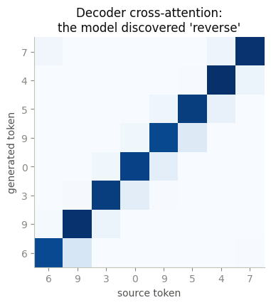

```python
src, dec_in, tgt = make_batch(1)
model.eval()
with torch.no_grad():
    model(src, dec_in)                                     # populates last_cross_attn

attn = model.decoder[-1].last_cross_attn[0].mean(0)        # average over heads: (Lq, Lk)

fig, ax = plt.subplots(figsize=(4.6, 4.2))
ax.imshow(attn, cmap="Blues")
ax.set_xticks(range(L_SEQ)); ax.set_xticklabels(src[0].tolist())
ax.set_yticks(range(L_SEQ)); ax.set_yticklabels(tgt[0].tolist())
ax.set_xlabel("source token"); ax.set_ylabel("generated token")
ax.set_title("Decoder cross-attention:\nthe model discovered 'reverse'")
ax.grid(False);
```

Nobody told the model to look at the source backwards — gradient descent found that attention pattern because it minimizes prediction error. This is the general story of Transformers: the architecture supplies *routing machinery*, and training discovers *what to route*. (In real translation models, cross-attention maps recover word alignments between languages the same way.)

## 16. Warmup & label smoothing

Two training details from the original paper that survive (in some form) in every modern LLM recipe:

**Learning-rate warmup.** Early in training, attention patterns and LayerNorm statistics are random; a full-size learning rate can wreck the model in the first few hundred steps. The "Noam" schedule ramps the LR linearly for `warmup` steps, then decays it as $1/\sqrt{step}$:

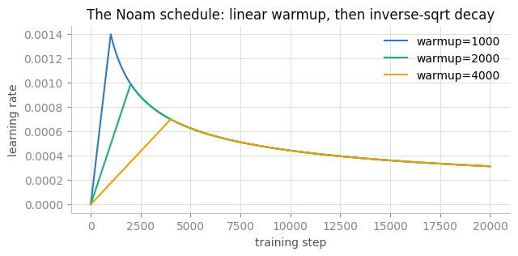

```python
def noam_lr(step, d_model=512, warmup=4000):
    step = max(step, 1)
    return d_model ** -0.5 * min(step ** -0.5, step * warmup ** -1.5)

steps = np.arange(1, 20000)
fig, ax = plt.subplots(figsize=(7, 3))
for w in [1000, 2000, 4000]:
    ax.plot(steps, [noam_lr(s, warmup=w) for s in steps], label=f"warmup={w}")
ax.set_xlabel("training step"); ax.set_ylabel("learning rate")
ax.set_title("The Noam schedule: linear warmup, then inverse-sqrt decay")
ax.legend(frameon=False);
```

**Label smoothing.** Instead of demanding probability 1.0 on the true token (which pushes logits toward infinity and makes the model overconfident), the target distribution gives the true token $1-\varepsilon$ and spreads $\varepsilon$ (typically 0.1) over the rest. One argument in PyTorch:

```
loss = F.cross_entropy(logits, targets, label_smoothing=0.1)
```

## 17. PyTorch built-ins

Everything we hand-built exists as a battle-tested module. In practice you reach for these (note `norm_first=True` — pre-LN, as we discussed — is *not* the default, for backwards-compatibility reasons):

```python
layer = nn.TransformerEncoderLayer(d_model=64, nhead=4, dim_feedforward=128,
                                   batch_first=True, norm_first=True, dropout=0.1)
encoder = nn.TransformerEncoder(layer, num_layers=2)
print("nn.TransformerEncoder:", tuple(encoder(torch.randn(2, 10, 64)).shape))

# The single most useful function: fused scaled-dot-product attention.
# On GPU this dispatches to FlashAttention-style kernels automatically.
q = torch.randn(2, 4, 10, 16)                       # (B, heads, L, d_head)
out = F.scaled_dot_product_attention(q, q, q, is_causal=True)
print("F.scaled_dot_product_attention:", tuple(out.shape))
```

```
nn.TransformerEncoder: (2, 10, 64)
F.scaled_dot_product_attention: (2, 4, 10, 16)
```

Guide to the zoo:

| You need | Reach for |
| --- | --- |
| attention inside your own module | `F.scaled_dot_product_attention` (fused, fast) |
| a standard encoder / decoder stack | `nn.TransformerEncoder` / `nn.TransformerDecoder` |
| the full 2017 architecture | `nn.Transformer` |
| a *pretrained* model | the Hugging Face `transformers` library |

From here on we still build from scratch — because part V's goal is to understand exactly what is inside a GPT.

## 18. The GPT architecture

Modern LLMs threw away half the Transformer. A **GPT is decoder-only**: no encoder, no cross-attention — just embeddings, $N$ blocks of (masked self-attention + FFN), a final LayerNorm, and a projection to vocabulary logits. Trained on one objective: **predict the next token**, at every position, over a huge corpus.

Our implementation adds two production touches: **weight tying** (the output projection reuses the embedding table) and a `past` argument in attention that lets us append previously computed keys/values — dormant for now, it becomes the **KV cache** in section 21.

```python
class CausalSelfAttention(nn.Module):
    def __init__(self, d_model, n_heads, dropout=0.1):
        super().__init__()
        self.n_heads, self.d_head = n_heads, d_model // n_heads
        self.wq = nn.Linear(d_model, d_model)
        self.wk = nn.Linear(d_model, d_model)
        self.wv = nn.Linear(d_model, d_model)
        self.wo = nn.Linear(d_model, d_model)
        self.drop = nn.Dropout(dropout)

    def forward(self, x, past=None):
        B, L, D = x.shape
        split = lambda t: t.view(B, L, self.n_heads, self.d_head).transpose(1, 2)
        q, k, v = split(self.wq(x)), split(self.wk(x)), split(self.wv(x))
        if past is not None:                        # reuse cached keys/values
            pk, pv = past
            k, v = torch.cat([pk, k], dim=2), torch.cat([pv, v], dim=2)
        P = k.shape[2] - L                          # number of cached positions
        att = q @ k.transpose(-2, -1) / math.sqrt(self.d_head)
        mask = torch.tril(torch.ones(L, P + L, dtype=torch.bool), diagonal=P)
        att = att.masked_fill(~mask, float("-inf"))
        att = self.drop(torch.softmax(att, dim=-1))
        out = (att @ v).transpose(1, 2).reshape(B, L, D)
        return self.wo(out), (k, v)

class GPTBlock(nn.Module):
    def __init__(self, d_model, n_heads, dropout=0.1):
        super().__init__()
        self.ln1 = nn.LayerNorm(d_model)
        self.ln2 = nn.LayerNorm(d_model)
        self.attn = CausalSelfAttention(d_model, n_heads, dropout)
        self.ffn = FeedForward(d_model, 4 * d_model, dropout)

    def forward(self, x, past=None):
        a, kv = self.attn(self.ln1(x), past)
        x = x + a
        x = x + self.ffn(self.ln2(x))
        return x, kv

class GPT(nn.Module):
    def __init__(self, vocab_size, block_size, d_model=96, n_heads=4,
                 n_layers=3, dropout=0.1):
        super().__init__()
        self.block_size = block_size
        self.tok_emb = nn.Embedding(vocab_size, d_model)
        self.pos_emb = nn.Embedding(block_size, d_model)     # learned positions (GPT-2 style)
        self.drop = nn.Dropout(dropout)
        self.blocks = nn.ModuleList([GPTBlock(d_model, n_heads, dropout)
                                     for _ in range(n_layers)])
        self.ln_f = nn.LayerNorm(d_model)
        self.head = nn.Linear(d_model, vocab_size, bias=False)
        self.head.weight = self.tok_emb.weight               # weight tying
        # GPT-2-style small init; essential with tying, else the tied output
        # head produces huge logits and a wild loss at step 0
        nn.init.normal_(self.tok_emb.weight, std=0.02)
        nn.init.normal_(self.pos_emb.weight, std=0.02)

    def forward(self, idx, pasts=None, pos_offset=0):
        B, L = idx.shape
        pos = torch.arange(pos_offset, pos_offset + L, device=idx.device)
        x = self.drop(self.tok_emb(idx) + self.pos_emb(pos))
        new_pasts = []
        for i, blk in enumerate(self.blocks):
            x, kv = blk(x, None if pasts is None else pasts[i])
            new_pasts.append(kv)
        return self.head(self.ln_f(x)), new_pasts

print("GPT class ready — same blocks as before, minus the encoder machinery")
```

```
GPT class ready — same blocks as before, minus the encoder machinery
```

## 19. Training a char-level GPT

We train on the opening of *Alice's Adventures in Wonderland* (public domain), tokenized at character level. The training data construction is beautifully simple — **the text is its own label**, shifted by one:

```
input :  "Alice was beginnin"
target:  "lice was beginning"
```

Every window of `block_size` characters gives `block_size` training examples at once.

```python
TEXT = '''Alice was beginning to get very tired of sitting by her sister on the bank, and of having nothing to do: once or twice she had peeped into the book her sister was reading, but it had no pictures or conversations in it, 'and what is the use of a book,' thought Alice 'without pictures or conversations?'

So she was considering in her own mind (as well as she could, for the hot day made her feel very sleepy and stupid), whether the pleasure of making a daisy-chain would be worth the trouble of getting up and picking the daisies, when suddenly a White Rabbit with pink eyes ran close by her.

There was nothing so very remarkable in that; nor did Alice think it so very much out of the way to hear the Rabbit say to itself, 'Oh dear! Oh dear! I shall be late!' (when she thought it over afterwards, it occurred to her that she ought to have wondered at this, but at the time it all seemed quite natural); but when the Rabbit actually took a watch out of its waistcoat-pocket, and looked at it, and then hurried on, Alice started to her feet, for it flashed across her mind that she had never before seen a rabbit with either a waistcoat-pocket, or a watch to take out of it, and burning with curiosity, she ran across the field after it, and fortunately was just in time to see it pop down a large rabbit-hole under the hedge.

In another moment down went Alice after it, never once considering how in the world she was to get out again.

The rabbit-hole went straight on like a tunnel for some way, and then dipped suddenly down, so suddenly that Alice had not a moment to think about stopping herself before she found herself falling down a very deep well.

Either the well was very deep, or she fell very slowly, for she had plenty of time as she went down to look about her and to wonder what was going to happen next. First, she tried to look down and make out what she was coming to, but it was too dark to see anything; then she looked at the sides of the well, and noticed that they were filled with cupboards and book-shelves; here and there she saw maps and pictures hung upon pegs. She took down a jar from one of the shelves as she passed; it was labelled 'ORANGE MARMALADE', but to her great disappointment it was empty: she did not like to drop the jar for fear of killing somebody, so managed to put it into one of the cupboards as she fell past it.

'Well!' thought Alice to herself, 'after such a fall as this, I shall think nothing of tumbling down stairs! How brave they'll all think me at home! Why, I wouldn't say anything about it, even if I fell off the top of the house!' (Which was very likely true.)

Down, down, down. Would the fall never come to an end? 'I wonder how many miles I've fallen by this time?' she said aloud. 'I must be getting somewhere near the centre of the earth. Let me see: that would be four thousand miles down, I think.'

Down, down, down. There was nothing else to do, so Alice soon began talking again. 'Dinah will miss me very much to-night, I should think!' (Dinah was the cat.) 'I hope they will remember her saucer of milk at tea-time. Dinah my dear! I wish you were down here with me! There are no mice in the air, I am afraid, but you might catch a bat, and that is very like a mouse, you know. But do cats eat bats, I wonder?' And here Alice began to get rather sleepy, and went on saying to herself, in a dreamy sort of way, 'Do cats eat bats? Do cats eat bats?' and sometimes, 'Do bats eat cats?' for, you see, as she could not answer either question, it did not much matter which way she put it.

Suddenly she came upon a little three-legged table, all made of solid glass; there was nothing on it except a tiny golden key, and Alice's first thought was that it might belong to one of the doors of the hall; but, alas! either the locks were too large, or the key was too small, but at any rate it would not open any of them. However, on the second time round, she came upon a low curtain she had not noticed before, and behind it was a little door about fifteen inches high: she tried the little golden key in the lock, and to her great delight it fitted!'''

# vocab over the text AND its uppercase form (we fine-tune on SHOUTING in section 26)
chars = sorted(set(TEXT + TEXT.upper()))
vocab_size = len(chars)
stoi = {ch: i for i, ch in enumerate(chars)}
itos = {i: ch for ch, i in stoi.items()}
encode = lambda s: [stoi[c] for c in s]
decode = lambda ids: "".join(itos[int(i)] for i in ids)

data = torch.tensor(encode(TEXT), dtype=torch.long)
n_val = len(data) // 10
train_data, val_data = data[:-n_val], data[-n_val:]
print(f"corpus: {len(data):,} chars | vocab: {vocab_size} | train/val: {len(train_data):,}/{len(val_data):,}")
```

```
corpus: 4,119 chars | vocab: 62 | train/val: 3,708/411
```

```
parameters: 353,952
```

```
step    0 | train 4.177 | val 4.181
```

```
step  100 | train 2.372 | val 2.366
```

```
step  200 | train 2.075 | val 2.424
```

```
step  300 | train 1.401 | val 2.554
```

```
step  400 | train 0.657 | val 3.022
```

```
step  500 | train 0.336 | val 3.473
```

```
step  600 | train 0.220 | val 3.672
```

```
step  700 | train 0.169 | val 3.945

trained in 175s on CPU
```

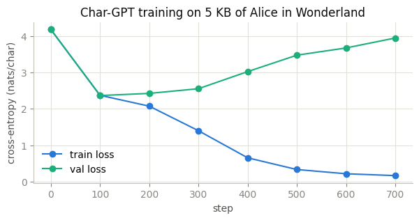

```python
BLOCK = 128

def get_batch(source, batch_size=24):
    ix = torch.randint(len(source) - BLOCK - 1, (batch_size,))
    x = torch.stack([source[i:i + BLOCK] for i in ix])
    y = torch.stack([source[i + 1:i + BLOCK + 1] for i in ix])   # inputs shifted by one
    return x, y

gpt = GPT(vocab_size, BLOCK, d_model=96, n_heads=4, n_layers=3, dropout=0.1)
print(f"parameters: {sum(p.numel() for p in gpt.parameters()):,}")

@torch.no_grad()
def estimate_loss(model, n_batches=20):
    model.eval()
    out = {}
    for name, source in [("train", train_data), ("val", val_data)]:
        losses = []
        for _ in range(n_batches):
            xb, yb = get_batch(source)
            logits, _ = model(xb)
            losses.append(F.cross_entropy(logits.view(-1, vocab_size), yb.view(-1)).item())
        out[name] = float(np.mean(losses))
    model.train()
    return out

opt = torch.optim.AdamW(gpt.parameters(), lr=1.5e-3, weight_decay=0.01)
history = {"step": [], "train": [], "val": []}

t0 = time.time()
gpt.train()
for step in range(701):
    if step % 100 == 0:
        ls = estimate_loss(gpt)
        history["step"].append(step)
        history["train"].append(ls["train"]); history["val"].append(ls["val"])
        print(f"step {step:4d} | train {ls['train']:.3f} | val {ls['val']:.3f}")
    xb, yb = get_batch(train_data)
    logits, _ = gpt(xb)
    loss = F.cross_entropy(logits.view(-1, vocab_size), yb.view(-1))
    opt.zero_grad(); loss.backward()
    torch.nn.utils.clip_grad_norm_(gpt.parameters(), 1.0)       # gradient clipping
    opt.step()
print(f"\ntrained in {time.time()-t0:.0f}s on CPU")

fig, ax = plt.subplots(figsize=(7, 3))
ax.plot(history["step"], history["train"], marker="o", label="train loss")
ax.plot(history["step"], history["val"], marker="o", label="val loss")
ax.set_xlabel("step"); ax.set_ylabel("cross-entropy (nats/char)")
ax.set_title("Char-GPT training on 5 KB of Alice in Wonderland")
ax.legend(frameon=False);
```

With ~5 KB of text and ~350 K parameters the model memorizes more than it generalizes (watch train and val loss separate) — that's expected and instructive: **the same code at a billion times the scale is a real LLM.** Let's hear it talk:

```python
@torch.no_grad()
def generate_simple(model, prompt, n_new, temperature=1.0):
    model.eval()
    idx = torch.tensor([encode(prompt)], dtype=torch.long)
    for _ in range(n_new):
        ctx = idx[:, -model.block_size:]                 # crop to context window
        logits, _ = model(ctx)
        probs = torch.softmax(logits[:, -1, :] / temperature, dim=-1)
        nxt = torch.multinomial(probs, 1)                # sample from the distribution
        idx = torch.cat([idx, nxt], dim=1)
    return decode(idx[0].tolist())

print(generate_simple(gpt, "Alice ", 300, temperature=0.8))
```

```
Alice wigho very much ould ther wor way to he he fell as shepasst it.

'Welll!' thought Alice to herself, 'after such a fall as this, I shalll think nothing dow stairs! How brave they'lll all think me at home! Why, I wouldn't say ay anything about it, even if I felll offffal the top of the house!' (Which
```

## 20. Sampling strategies

A language model outputs a probability *distribution*; how you pick from it changes the personality of the output. The standard toolkit:

- **Greedy** — always take the argmax. Deterministic; loops and repeats easily.
- **Temperature** $T$ — divide logits by $T$ before softmax. $T<1$ sharpens (safer), $T>1$ flattens (wilder), $T \to 0$ is greedy.
- **Top-k** — keep only the $k$ highest logits, renormalize. Cuts off the long junk tail.
- **Top-p (nucleus)** — keep the smallest set of tokens whose cumulative probability exceeds $p$: adapts the cutoff to the model's confidence.

```python
def sample_next(logits, temperature=1.0, top_k=None, top_p=None, greedy=False):
    if greedy:
        return logits.argmax(-1, keepdim=True)
    logits = logits / max(temperature, 1e-8)
    if top_k is not None:
        kth = torch.topk(logits, top_k).values[..., -1, None]
        logits = logits.masked_fill(logits < kth, float("-inf"))
    if top_p is not None:
        s_logits, s_idx = torch.sort(logits, descending=True)
        probs = torch.softmax(s_logits, dim=-1)
        drop = probs.cumsum(-1) - probs > top_p         # tokens past the nucleus
        s_logits[drop] = float("-inf")
        logits = torch.full_like(logits, float("-inf")).scatter(-1, s_idx, s_logits)
    return torch.multinomial(torch.softmax(logits, -1), 1)

@torch.no_grad()
def generate(model, prompt, n_new, **kw):
    model.eval()
    idx = torch.tensor([encode(prompt)], dtype=torch.long)
    for _ in range(n_new):
        logits, _ = model(idx[:, -model.block_size:])
        idx = torch.cat([idx, sample_next(logits[:, -1, :], **kw)], dim=1)
    return decode(idx[0].tolist())

for name, kw in [("greedy", dict(greedy=True)),
                 ("temperature 0.5", dict(temperature=0.5)),
                 ("temperature 1.3", dict(temperature=1.3)),
                 ("top-k 8", dict(temperature=0.9, top_k=8)),
                 ("top-p 0.9", dict(temperature=0.9, top_p=0.9))]:
    torch.manual_seed(1)
    print(f"--- {name} ---")
    print(generate(gpt, "Alice ", 120, **kw), "\n")
```

```
--- greedy ---
```

```
Alice ther fier sld after it, and fortunately was just in time to seee it pop down a large rabbit-hole under thedge.

In anoth

--- temperature 0.5 ---
```

```
Alice ther fit, and fortunately was just in time to see it pop down a large rabbit-hole under thedge.

In another moment down

--- temperature 1.3 ---
```

```
Alice ther fit, and wenoth sud ble atherer feereet, ied forshay fnacupbok-sGhe min very mat teararara sarara ilea semarand my

--- top-k 8 ---
```

```
Alice ther fit, and fortunately was just in to ime t seee it pop down a large rabbit-hole under thedge.
In another moment down

--- top-p 0.9 ---
```

```
Alice ther fit, and fortunately was just in time to see it pop down a large rabit-hole under the hedge.
In anotherse moment do
```

## 21. The KV cache

Look at the generation loop above: to add **one** token we re-run the model on the **entire** sequence, recomputing keys and values for tokens that haven't changed. Cost per token grows with context length — quadratic overall.

The fix used by every serving system: **cache each layer's K and V** tensors. Per new token, compute q/k/v for *that token only*, append k,v to the cache, and attend against it. This is exactly why our `CausalSelfAttention` has the `past` argument:

```python
@torch.no_grad()
def generate_cached(model, prompt, n_new):
    model.eval()
    idx = torch.tensor([encode(prompt)], dtype=torch.long)
    logits, pasts = model(idx)                            # prefill: process prompt once
    nxt = logits[:, -1:].argmax(-1)
    for _ in range(n_new - 1):
        idx = torch.cat([idx, nxt], dim=1)
        logits, pasts = model(nxt, pasts=pasts,           # feed ONE token + the cache
                              pos_offset=idx.shape[1] - 1)
        nxt = logits[:, -1:].argmax(-1)
    return decode(torch.cat([idx, nxt], dim=1)[0].tolist())

prompt, n_new = "Alice ", 120

t0 = time.time(); out_slow = generate(gpt, prompt, n_new, greedy=True); t_slow = time.time() - t0
t0 = time.time(); out_fast = generate_cached(gpt, prompt, n_new);       t_fast = time.time() - t0

print("identical output:", out_slow == out_fast)
print(f"no cache : {t_slow*1000:6.0f} ms")
print(f"KV cache : {t_fast*1000:6.0f} ms   ({t_slow/t_fast:.1f}x faster)")
```

```
identical output: True
no cache :    437 ms
KV cache :    261 ms   (1.7x faster)
```

Same tokens, roughly twice as fast even at this tiny scale — and the gap widens with context length (recompute is $O(n^2)$ per token vs $O(n)$ with the cache). The trade is **memory**: the cache stores $2 \times \text{layers} \times \text{heads} \times d_{head}$ values per token, which for a 70B model at 128 K context runs to tens of gigabytes. Managing that memory (paging, quantizing, sharing it across requests — e.g. vLLM's PagedAttention) is a large part of LLM serving engineering, and reducing it is one motivation for GQA in section 23.

## 22. The model family: BERT vs GPT vs T5

Everything in the Transformer family is the blocks you built, arranged three ways:

|  | **BERT** (encoder-only) | **GPT** (decoder-only) | **T5** (encoder–decoder) |
| --- | --- | --- | --- |
| Attention | bidirectional | causal | bi (enc) + causal (dec) + cross |
| Pretraining objective | masked-token prediction | next-token prediction | span corruption |
| Sees future context? | yes | no | encoder: yes |
| Can generate text? | not naturally | **yes** — its whole job | yes |
| Typical use | embeddings, classification, retrieval | chat, code, everything generative | translation, summarization |

The two pretraining objectives differ only in how you slice the data:

```python
ids = torch.tensor(encode("alice was beginning"))

# Causal LM (GPT): predict every next token
clm_input, clm_target = ids[:-1], ids[1:]
print("CLM  input :", decode(clm_input.tolist()))
print("CLM  target:", decode(clm_target.tolist()))

# Masked LM (BERT): hide random tokens, predict only those
torch.manual_seed(3)
masked = ids.clone()
mask_pos = torch.rand(len(ids)) < 0.15
masked[mask_pos] = stoi["_"] if "_" in stoi else 0
print("\nMLM  input :", "".join("_" if m else c for c, m in zip(decode(ids.tolist()), mask_pos)))
print("MLM  labels: only the masked positions")
```

```
CLM  input : alice was beginnin
CLM  target: lice was beginning

MLM  input : __i_e_was be_i_ning
MLM  labels: only the masked positions
```

Why did decoder-only win? Next-token prediction turns **every token of the corpus into a training signal**, needs no special mask tokens, and — the decisive part — the trained model *is* a generator, so one architecture handles chat, code, translation, and reasoning by simply continuing text. BERT-style encoders survive where you want one vector per text: embeddings, search, and classification.

## 23. Modern internals: RoPE, RMSNorm, SwiGLU, GQA

A 2024-era LLM (LLaMA, Mistral, Qwen...) differs from our GPT in four standard upgrades.

**RoPE — rotary position embeddings.** Instead of *adding* position vectors, RoPE *rotates* each (q, k) pair of dimensions by an angle proportional to the token's position. The magic: a dot product between a query rotated by $m\theta$ and a key rotated by $n\theta$ depends only on $m - n$ — attention sees **relative** position, which generalizes far better to long contexts:

```python
def rope_apply(x, pos, base=10000.0):
    d = x.shape[-1]; half = d // 2
    freqs = base ** (-torch.arange(half, dtype=torch.float32) / half)
    angle = pos * freqs                                  # one angle per dimension pair
    x1, x2 = x[..., :half], x[..., half:]
    return torch.cat([x1 * torch.cos(angle) - x2 * torch.sin(angle),
                      x1 * torch.sin(angle) + x2 * torch.cos(angle)], dim=-1)

q, k = torch.randn(32), torch.randn(32)
near = rope_apply(q, 5) @ rope_apply(k, 3)               # positions (5, 3): offset 2
far  = rope_apply(q, 105) @ rope_apply(k, 103)           # positions (105, 103): offset 2
diff = rope_apply(q, 105) @ rope_apply(k, 3)             # offset 102

print(f"score at offset 2 (positions 5,3)    : {near:.6f}")
print(f"score at offset 2 (positions 105,103): {far:.6f}   <- identical: only offset matters")
print(f"score at offset 102                  : {diff:.6f}   <- different offset, different score")
```

```
score at offset 2 (positions 5,3)    : -3.627995
score at offset 2 (positions 105,103): -3.627997   <- identical: only offset matters
score at offset 102                  : -3.533691   <- different offset, different score
```

**RMSNorm** — LayerNorm without the mean subtraction and bias: just rescale by the root-mean-square. One less reduction, fewer parameters, empirically just as good.

**SwiGLU** — the FFN becomes a *gated* unit: one branch produces content, a second branch (through a SiLU) gates it elementwise. Three weight matrices instead of two, consistently better perplexity at equal parameter count.

```python
class RMSNorm(nn.Module):
    def __init__(self, d, eps=1e-6):
        super().__init__()
        self.g = nn.Parameter(torch.ones(d))
        self.eps = eps
    def forward(self, x):
        return self.g * x / torch.sqrt((x ** 2).mean(-1, keepdim=True) + self.eps)

class SwiGLU(nn.Module):
    def __init__(self, d_model, d_ff):
        super().__init__()
        self.w_gate = nn.Linear(d_model, d_ff, bias=False)
        self.w_up   = nn.Linear(d_model, d_ff, bias=False)
        self.w_down = nn.Linear(d_ff, d_model, bias=False)
    def forward(self, x):
        return self.w_down(F.silu(self.w_gate(x)) * self.w_up(x))

x = torch.randn(2, 5, 64)
print("RMSNorm :", tuple(RMSNorm(64)(x).shape))
print("SwiGLU  :", tuple(SwiGLU(64, 172)(x).shape),
      " (d_ff is ~2/3 of 4d to keep parameter count equal)")
```

```
RMSNorm : (2, 5, 64)
SwiGLU  : (2, 5, 64)  (d_ff is ~2/3 of 4d to keep parameter count equal)
```

**GQA — grouped-query attention.** The KV cache (section 21) stores K and V for every head. GQA keeps all the *query* heads but shares each K/V head among a **group** of query heads (e.g. 32 query heads, 8 KV heads) — cutting KV-cache memory 4× with negligible quality loss. MQA is the extreme case: one shared KV head.

Putting it together, a LLaMA-style block is: `x = x + Attn_RoPE_GQA(RMSNorm(x))` then `x = x + SwiGLU(RMSNorm(x))` — structurally identical to what you built, with each part swapped for its refined version.

## 24. The quadratic bottleneck & efficient attention

Attention's $n \times n$ score matrix is its scaling curse. Materializing it in fp32 for a 12-head model:

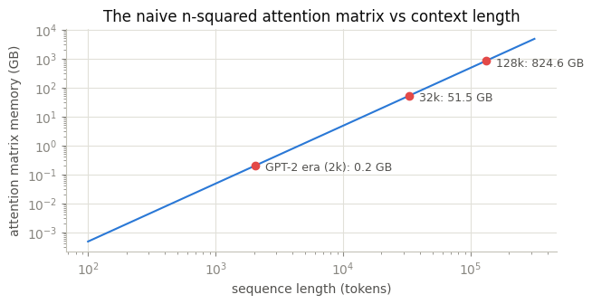

```python
L = np.logspace(2, 5.5, 200)                       # 100 ... ~316k tokens
gbytes = (L ** 2) * 12 * 4 / 1e9                   # heads x fp32 bytes, batch of 1

fig, ax = plt.subplots(figsize=(7, 3.2))
ax.loglog(L, gbytes)
for n, name in [(2048, "GPT-2 era (2k)"), (32768, "32k"), (131072, "128k")]:
    g = n ** 2 * 12 * 4 / 1e9
    ax.scatter([n], [g], color=PALETTE[5], zorder=3)
    ax.annotate(f"{name}: {g:,.1f} GB", (n, g), textcoords="offset points",
                xytext=(8, -4), fontsize=9, color="#52514e")
ax.set_xlabel("sequence length (tokens)")
ax.set_ylabel("attention matrix memory (GB)")
ax.set_title("The naive n-squared attention matrix vs context length");
```

At 128 K context the naive score matrix alone would need ~800 GB — yet real models run such contexts routinely. How:

- **FlashAttention** (the big one): never materialize the matrix. Compute attention in tiles that fit in fast on-chip SRAM, maintaining a running softmax. Same exact result, memory drops from $O(n^2)$ to $O(n)$. This is what `F.scaled_dot_product_attention` dispatches to on GPU — the math you wrote in section 6, reorganized for the memory hierarchy.
- **Sliding-window attention** (Mistral): each token attends only to the previous $w$ tokens; stacked layers still propagate information across the full sequence ($w \times$ layers reach).
- **Sparse / linear-attention families** (Longformer, Performer, state-space models like Mamba): change the math to sub-quadratic, trading some quality or exactness.

Compute (as opposed to memory) is still $O(n^2)$ for exact attention — that, plus the KV cache, is why long-context tokens cost more to serve.

## 25. Counting parameters & scaling laws

You can size any GPT in your head. Per layer: attention has $4d^2$ weights ($W_Q, W_K, W_V, W_O$), the 4×-expanded FFN has $8d^2$ — so **~$12 d^2$ per layer**, plus $V \times d$ for the (tied) embedding. Let's verify against our actual model and then size the GPT-2/3 family:

```python
def gpt_params(n_layers, d_model, vocab, block=0):
    per_layer = 12 * d_model ** 2       # 4d^2 attention + 8d^2 FFN (biases/norms ~ negligible)
    return n_layers * per_layer + vocab * d_model + block * d_model

ours_formula = gpt_params(3, 96, vocab_size, BLOCK)
ours_actual = sum(p.numel() for p in gpt.parameters())
print(f"our GPT   formula {ours_formula:>13,}   actual {ours_actual:>13,}")

for name, nl, d, V in [("GPT-2 small", 12, 768, 50257), ("GPT-2 XL", 48, 1600, 50257),
                       ("GPT-3", 96, 12288, 50257)]:
    print(f"{name:11s} formula {gpt_params(nl, d, V):>15,}")
```

```
our GPT   formula       350,016   actual       353,952
GPT-2 small formula     123,532,032
GPT-2 XL    formula   1,554,971,200
GPT-3       formula 174,563,733,504
```

The formula lands within a few percent of the published sizes (117 M, 1.5 B, 175 B). Two scaling facts every practitioner should know:

- **Loss falls as a power law** in parameters, data, and compute (Kaplan et al. 2020) — smooth and predictable over many orders of magnitude, which is why labs can forecast a model's quality before training it.
- **Chinchilla optimality** (Hoffmann et al. 2022): for a fixed compute budget, train a model on roughly **20 tokens per parameter**. GPT-3 was undertrained by this measure (~2 tokens/param); modern models often train far *past* 20 (LLaMA-3: 100+) because inference cost — which scales with model size, not training tokens — dominates total spend.

## 26. Fine-tuning & LoRA

Pretrained weights are a starting point; **fine-tuning** adapts them to your task. Full fine-tuning updates every weight — for a 70 B model that means 70 B gradients, optimizer states, and a full copy per task.

**LoRA** (Low-Rank Adaptation): freeze the base weights and learn only a low-rank *update* $\Delta W = BA$, where $A \in \mathbb{R}^{r \times d}$ and $B \in \mathbb{R}^{d \times r}$ with rank $r$ as small as 4–16. The layer computes $Wx + \tfrac{\alpha}{r} BAx$. Because $B$ starts at zero, training begins *exactly* at the pretrained model and moves away smoothly:

```python
class LoRALinear(nn.Module):
    def __init__(self, base, r=8, alpha=16):
        super().__init__()
        self.base = base                                          # frozen pretrained layer
        self.A = nn.Parameter(torch.randn(r, base.in_features) * 0.01)
        self.B = nn.Parameter(torch.zeros(base.out_features, r))  # zero: start = base model
        self.scale = alpha / r
    def forward(self, x):
        return self.base(x) + (x @ self.A.T) @ self.B.T * self.scale

for p in gpt.parameters():
    p.requires_grad_(False)                       # freeze the whole pretrained model
for blk in gpt.blocks:                            # adapt only q and v projections (standard)
    blk.attn.wq = LoRALinear(blk.attn.wq)
    blk.attn.wv = LoRALinear(blk.attn.wv)

total = sum(p.numel() for p in gpt.parameters())
trainable = sum(p.numel() for p in gpt.parameters() if p.requires_grad)
print(f"total params: {total:,} | trainable (LoRA only): {trainable:,} "
      f"({trainable/total:.1%})")
```

```
total params: 363,168 | trainable (LoRA only): 9,216 (2.5%)
```

Our fine-tuning "task": teach the model to WRITE IN UPPERCASE — same story, different style, so the effect is unmistakable. We train **only the LoRA matrices** (~2% of weights) on the uppercased corpus:

```python
print("before fine-tuning:")
torch.manual_seed(7)
print(generate(gpt, "ALICE", 100, temperature=0.8), "\n")

data_up = torch.tensor(encode(TEXT.upper()), dtype=torch.long)
opt = torch.optim.AdamW([p for p in gpt.parameters() if p.requires_grad], lr=1e-3)

gpt.train()
t0 = time.time()
for step in range(400):
    ix = torch.randint(len(data_up) - BLOCK - 1, (24,))
    xb = torch.stack([data_up[i:i + BLOCK] for i in ix])
    yb = torch.stack([data_up[i + 1:i + BLOCK + 1] for i in ix])
    logits, _ = gpt(xb)
    loss = F.cross_entropy(logits.view(-1, vocab_size), yb.view(-1))
    opt.zero_grad(); loss.backward(); opt.step()
print(f"LoRA fine-tuned 400 steps in {time.time()-t0:.0f}s | final loss {loss.item():.3f}\n")

print("after fine-tuning (only LoRA weights changed):")
torch.manual_seed(7)
print(generate(gpt, "ALICE", 100, temperature=0.8))
```

```
before fine-tuning:
```

```
ALICE'' hould.'I thopey w wishere felll r raf reehember saucer of milk at tea-time. Dinah my dear! I wish
```

```
LoRA fine-tuned 400 steps in 58s | final loss 2.803

after fine-tuning (only LoRA weights changed):
```

```
ALICE OFHOON ADWSIIIPEG
RNG (N TOR NNGOROON SH HLE HOR, AN WHG SHESWSMAT TEROSWAS S L TIE WE WE TO HON S
```

The base weights are byte-for-byte unchanged — delete the adapters and the original model is back; keep one tiny adapter file per task and swap them at load time. This is how most real-world LLM customization ships. Related techniques you'll meet: **QLoRA** (LoRA on a 4-bit-quantized base), instruction tuning (SFT), and RLHF/DPO — all post-training stages layered on the same frozen-backbone idea.

## 27. Debugging Transformers

Transformers fail in characteristic ways. The debugging kit, in the order to apply it:

1. **Check the loss at step 0.** With random weights the model should be exactly as good as guessing: loss $\approx \ln(V)$. Much lower → data leakage; much higher → broken init or a wrong mask.
2. **Overfit one batch.** A correct model+loss+optimizer must drive one batch's loss to ~0. If it can't, the bug is in the code, not the hyperparameters.
3. **Verify the causal mask** — the classic silent bug. Shift the *inputs* and check that *past* predictions don't change; or just look at the attention matrix (section 7).
4. **Watch gradient norms.** Spikes → lower LR or clip; zeros → dead path, wrong `requires_grad`, or saturated softmax (did you forget $\sqrt{d_k}$?).

```python
tiny = GPT(vocab_size, block_size=64, d_model=64, n_heads=4, n_layers=2, dropout=0.0)

# check 1: initial loss should be ~ln(vocab)
xb, yb = get_batch(train_data, batch_size=4)
xb, yb = xb[:, :64], yb[:, :64]
logits, _ = tiny(xb)
init = F.cross_entropy(logits.reshape(-1, vocab_size), yb.reshape(-1)).item()
print(f"check 1 — initial loss {init:.3f} vs ln({vocab_size}) = {math.log(vocab_size):.3f}")

# check 2: a healthy model can memorize one batch
opt = torch.optim.AdamW(tiny.parameters(), lr=3e-3)
for step in range(301):
    logits, _ = tiny(xb)
    loss = F.cross_entropy(logits.reshape(-1, vocab_size), yb.reshape(-1))
    opt.zero_grad(); loss.backward()
    grad_norm = torch.nn.utils.clip_grad_norm_(tiny.parameters(), 1.0)   # check 4, for free
    opt.step()
    if step % 100 == 0:
        print(f"check 2 — step {step:3d}: loss {loss.item():.4f} | grad norm {grad_norm:.2f}")
print("one batch memorized -> the architecture, loss, and optimizer are wired correctly")
```

```
check 1 — initial loss 4.075 vs ln(62) = 4.127
check 2 — step   0: loss 4.0753 | grad norm 2.15
```

```
check 2 — step 100: loss 0.0104 | grad norm 0.02
```

```
check 2 — step 200: loss 0.0036 | grad norm 0.01
```

```
check 2 — step 300: loss 0.0019 | grad norm 0.00
one batch memorized -> the architecture, loss, and optimizer are wired correctly
```

Beyond these: log everything per-layer when things get weird (activation std, attention entropy), keep a fixed eval prompt to eyeball generations during training, and change **one thing at a time** — Transformer hyperparameters interact (LR with warmup with batch size), and superstition accumulates fast when you change three knobs per run.

## 28. Where to go from here

You have now built, trained, inspected, accelerated, and fine-tuned Transformers from raw matrices up. What you built maps directly onto the literature:

**The papers, in reading order**

- *Attention Is All You Need* (Vaswani et al., 2017) — sections 5–16 of this notebook.
- *BERT* (Devlin et al., 2018) and *Language Models are Few-Shot Learners* (GPT-3, 2020) — the encoder and decoder paths diverge.
- *Scaling Laws* (Kaplan, 2020) and *Chinchilla* (Hoffmann, 2022) — section 25.
- *RoFormer* (RoPE, 2021), *FlashAttention* (Dao, 2022), *LoRA* (Hu, 2021) — sections 21–26.
- *LLaMA* (2023) — the modern open recipe: everything from section 23 in one model.

**Code to study next**

- **nanoGPT** (Karpathy) — our sections 18–21, scaled to real GPT-2 reproduction.
- **Hugging Face `transformers`** — pretrained everything; compare their `GPT2Model` source with your GPT class and you'll find the same blocks.

**In this series**: `deep_learning_basics_to_expert.ipynb` (backprop, CNNs, RNNs — the road here), `pytorch_basics_to_expert.ipynb` (the library itself).

The single most valuable exercise: **pick a small dataset you like and train a GPT on it** — song lyrics, chess games, your own notes. Everything you need is in this notebook.